# Project3 Report

Zhuodiao Kuang, Shaolei Ma, Peng Su, Yilei Yang

2024-05-02

# Introduction

The advent of single-cell RNA sequencing (scRNA-seq)[1] has revolutionized our understanding of cellular biology by enabling gene expression analysis at the single-cell level. This cutting-edge technology provides insights into the intricate details of cell functions and heterogeneity within cell populations. Cell heterogeneity, which refers to the variation in gene expression among cells of the same type, poses a significant challenge in biological research. Understanding this variability is crucial, particularly in the context of diseases like cancer, where cell population dynamics play a key role in disease progression and treatment responses.

In this report, we delve into the analysis of scRNA-seq data from breast cancer tumors, focusing on 558 genes across 716 cells. The primary objective is to employ Principal Component Analysis (PCA) to reduce the dimensionality of our dataset, thereby simplifying the complex gene expression data while retaining the most significant variables for further analysis. By determining the optimal number of principal components, we can capture the essential variability of gene expressions, which is crucial for accurate clustering and analysis.

Following PCA[2], we utilize a Gaussian-Mixture Model (GMM)[3] and an Expectation-Maximization (EM) algorithm[4] to cluster the cells based on their gene expression profiles. This approach helps in identifying distinct cell subtypes within the breast cancer tumors, which may differ in their biological characteristics and behavior. By analyzing these clusters, we aim to uncover specific gene-expression signatures using ‘limma’ package in ‘R’[5] that distinguish between the subpopulations, providing valuable insights into the underlying biology of breast cancer. This analysis not only enhances our understanding of tumor biology but also paves the way for targeted therapeutic strategies that could be more effective given the heterogeneity of the tumor cells.

This comprehensive approach to analyzing scRNA-seq data underscores the importance of advanced statistical techniques in extracting meaningful information from complex biological datasets, which is fundamental in advancing our understanding of diseases at the molecular level.

# Method

## Principal Component Analysis (PCA)

To illustrate the mathematical foundation of Principal Component Analysis (PCA), here are the key steps and formulas involved. First, we standardize the data. This means transforming the data so that each feature has a mean (average) of zero and a standard deviation of one. The standardization formula for each data point $x$ in feature $j$ is:
$$x' = \frac{x - \mu_j}{\sigma_j}$$
where $\mu_j$ is the mean and $\sigma_j$ is the standard deviation of the feature $j$.

Next, we calculate the covariance matrix, which expresses the covariance (joint variability) of the variables. If $X$ is a matrix of $n$ observations with $d$ variables, then the covariance matrix $C$ is given by:
$$C = \frac{1}{n-1} X^T X$$
where $X^T$ is the transpose of matrix $X$.

Then, the eigenvalues and eigenvectors of the covariance matrix are calculated. This step finds the principal components (directions of maximum variance). If $C$ is the covariance matrix, then the eigenvalues $\lambda$ and eigenvectors $v$ satisfy:
$$Cv = \lambda v$$
The top $k$ eigenvectors (where $k$ is the number of components you choose to keep) are selected, corresponding to the largest $k$ eigenvalues. These eigenvectors are used to form a feature vector $V_k$. Finally, transform the original data matrix $X$ into a new matrix $Y$ of reduced dimensions using the feature vector $V_k$:
$$Y = X V_k$$
Here, $Y$ is the matrix of the data projected onto the first $k$ principal components. This process effectively reduces the dimensionality of the data, focusing on the most significant variance aspects while losing the least amount of information possible.

## K-means

To detect the number of clusters, we first use K-means, the unsupervised learning method, to obtain an approximate range of number of clusters. Based on the two plots below, cluster sizes ranging from $2, 3, \cdots, 10$ is taken into consideration.

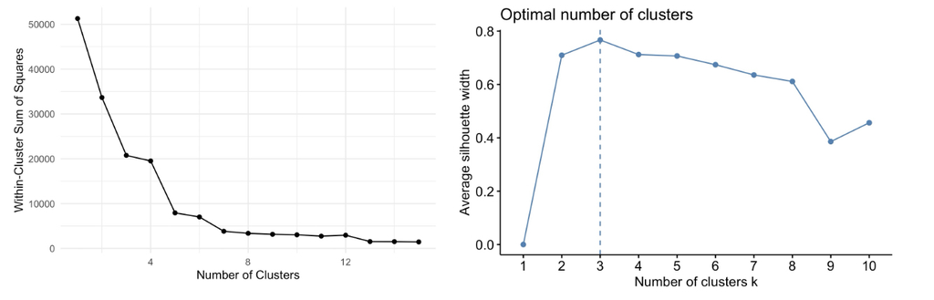

Figure 1 and 2: Comparisons of different cluster sizes

## Guassian Mixture Model

After determining the number of components using PCA, the Gaussian Mixture Model (GMM) is introduced as a way of clustering. The main assumption of GMM is that there are a certain number of Gaussian distributions. Furthermore, each of these Gaussian distributions represent a specific cluster. Suppose we have $k$ clusters. Let $X_i$ denote each individual cell, then we have $X\sim N(\mu_j,\Sigma_j)$ with probability $p_j,\,j=1,2,\cdots,k.$

The density of $X$ is thus
$$f(\mathbf x; \boldsymbol \mu, \Sigma) =
\frac{\text{exp} (-\frac{1}{2}(\boldsymbol x - \boldsymbol
\mu)^T\Sigma^{-1}(\boldsymbol x - \boldsymbol
\mu))}{\sqrt{{(2\pi)^p|\Sigma|}}}$$
where $\boldsymbol \mu$ is $p$-dimensional mean, and $\Sigma$ is $p\times p$ variance-covariance matrix;

Through multiplying density of $X_i$ and possibility for each $X_i$ and summing up the product for each cluster, an observed likelihood of $(x_1,...,x_n)$ can be calculated as below:
$$L(\theta; \mathbf x_1,\mathbf
x_2,...,\mathbf x_n) = \prod_{i=1}^n \sum_{j = 1}^k p_j f(\mathbf x_i;
\boldsymbol \mu_j, \Sigma_j)$$
In order to distinguish which data point belongs to which cluster, a latent variable $\gamma_i$ is used as the cluster indicator that indicates the probability that each data point belongs to each cluster of the GMM. Hence, let $\mathbf \gamma_i = (\gamma_{i,1},...,\gamma_{i,k})\in \mathbb R^k$ as the cluster indicator of $\mathbf x_i$, which takes form $(0, 0,...,0,1,0,0)$ with $\gamma_{i,j} =I\{ \mathbf x_i\mbox{ belongs to cluster } j\}$.

The distribution of $\mathbf \gamma_i$ is
$$f(\mathbf \gamma_i) =
\prod_{j= 1}^k p_j^{\gamma_i,j}$$

Through multiplying the distribution of $\gamma_i$ with the conditional distribution of $\mathbf x_i$ given $\mathbf \gamma_i$, which is $f(\mathbf x_i|\mathbf \gamma_i) = \prod_{j= 1}^k f(\mathbf x_i; \boldsymbol \mu_j, \Sigma_j)^{\gamma_i,j}$, the complete likelihood function can be calculated as below using the conditional distribution formula:

$$L(\theta; \mathbf x,\mathbf \gamma) =
\prod_{i=1}^n \prod_{j=1}^k [p_j f(\mathbf x_i; \boldsymbol \mu_j,
\Sigma_j)] ^{\gamma_{i,j}}$$
Furthermore, the complete log-likelihood becomes

$$\ell(\theta; \mathbf x,\mathbf \gamma) =
\sum_{i=1}^n \sum_{j=1}^k \gamma_{i,j} [\log p_i + \log f(\mathbf x_i;
\boldsymbol \mu_j, \Sigma_j)] = \sum_{i=1}^n \sum_{j=1}^k \gamma_{i,j}
[\log p_i-1/2\log|\Sigma|-1/2 (\mathbf x_i-\boldsymbol \mu_j)^\top\Sigma
(\mathbf x_i-\boldsymbol \mu_j)]$$

## Expectation-Maximization Algorithm:

**E-step**

Following, the GMM model is integrated into the Expectation-Maximization algorithm. In the Expectation step, an initial guess of parameters in the GMM model is taken using a pre-determined cluster size (k) value, including the means $\mu_k$, co-variances $\Sigma_k$, and mixing coefficients $p_k$. Using these initial parameters of the GMM model, the responsibilities can be evaluated as following:

$$\gamma_{i, k} ^{(t)}=
\frac{p_k^{(t)}f(\mathbf x_i|\boldsymbol \mu_k^{(t)}, \Sigma_k^{(t)})}
{\sum_{j=1}^K p_j^{(t)}f(\mathbf x_i|\boldsymbol \mu_j^{(t)},
\Sigma_j^{(t)})}$$
where $t$ denote the $t_{th}$ iteration;

In the numerator of this function, the mixing coefficient $p_k$ is multiplied by the possibility density function of $X_i$ under component k. This multiplication results in the prior probability of data point $x_i$ belonging to component k.

The denominator of this function is the sum of the prior probabilities across all components j (where $j = 1, 2, \cdots,k$). This normalization step ensure that the responsibilities sum up to 1 for each data point.

**M-step**

Next, in the Maximization step, the parameters of the GMM (means, co-variances, and mixing coefficients) based on the computed responsibilities for each cluster that was obtained from the Expectation step.

First, let $n_k = \sum_{i=1}^n \gamma_{i, k}$ The updated mixing coefficient $p_k$ for component k is calculated as the average responsibility assigned to that component:
$$p_k^{(t+1)} = \frac{n_k}{n}$$

The mean $\mu_k$ of each component is updated using a weighted average of data points, where the weights are the responsibilities $\gamma_i$ assigned to each data point for component k:
$$\boldsymbol \mu_k^{(t+1)} = \frac{1}{n_k}
\sum_{i=1}^n \gamma_{i, k} \mathbf x_i$$

Using the updated components means, the co-variance matrix $\Sigma_k$ of each component is updated based on the responsibility-weighted sum of squared distances between the data points and the component means:

$$\Sigma_k^{(t+1)} = \frac{1}{n_k}
\sum_{i=1}^n \gamma_{i, k} (\mathbf x_i - \boldsymbol
\mu_k^{(t+1)})(\mathbf x_i - \boldsymbol \mu_k^{(t+1)})^T$$

In each iteration t, the E-M algorithm is repeated to update theses parameters until an optimization of likelihood function is achieved. After an optimization is achieved, the assignment of each data point to a specific cluster is done based on the largest value of latent variable for each cell. If two clusters have the same parameters, the data point would be randomly assigned to one cluster.

## Gene-expression signatures

### Data normalization and precision weights estimation

The `voom` package is used to transform and normalize the sparse expression data for comparability. It converts expression levels to $log_2$ scale (adding 0.5 for zeros) and normalizes the transformed matrix. Then it fits a linear model to assess expression differences between clusters. Using the `LOWESS` method, it predicts variance from the relationship between the square root of residual standard deviations and average log-counts. This estimated variance’s inverse ($\frac{1}{variance}$) serves as a precision weight to correct heteroscedasticity, enabling weighted least squares fitting in the linear model analysis.

### Linear model fitting and coefficient updating

After data processing, the `lmFit` function is applied to fit linear models row-wise to the expression matrix, which incorporates variance-based weights for each gene. The design matrix indicates clusters for each sample. These models evaluates gene expression relationships with cluster variables. After this evaluation, a contrast matrix is defined for specific pairwise cluster comparisons. The `contrasts.fit` function integrates these comparisons into each gene’s model, facilitating statistical tests that yield fold changes, F-statistics, and p-values between groups.

### Improvements in statistical testing

To increase the robustness and stability of statistical analysis, Empirical Bayes (EB) is utilized to refine the inference of linear model coefficients (fold changes). EB calculates a prior variance distribution from the variance across all genes and a weighted average. This prior variance is then combined with each gene’s individual sample variance to estimate a posterior variance, effectively reducing uncertainty in statistical tests reliant on small-sample variances. This approach adjusts the reliance on prior variance when individual gene variances are based on limited data. Following indicates related formulas:

- Prior variance

$$\sigma^2_{\text{prior}} =
\frac{\sum_{i=1}^n w_i \sigma^2_i}{\sum_{i=1}^n w_i}$$
where $\sigma^2_i$ is the variance of ith gene, $w_i$ is the weight of ith gene, and $n$ is the total number of genes.

- Posterior Variance

$$\sigma^2_{\text{posterior}, i} =
\frac{1}{\frac{1}{\sigma^2_{\text{prior}}} +
\frac{1}{\sigma^2_i}}$$

- F test

$$F = \frac{(\text{Model SS} - \text{Error
SS}) / \text{df}_{\text{model}}}{\sigma^2_{\text{posterior}} /
\text{df}_{\text{error}}}$$
where $Model SS$ is model sum of squares, $Error SS$ is residual sum of squares, $df$ and is degrees of freedom.

# Results

## Guassian Mixture Model and Expectation-Maximization Algorithm:

Through implementing the E-M algorithm is implemented in R (Appendix: E-M Algorithm), updated parameters, including $\mu_k$, $\Sigma_k$, and $p_k$, are obtained for each cluster. The marginal likelihood can be then calculated using the GMM function.

Through comparing the marginal likelihood for cluster sizes ranging from $2, 3, \cdots, 10$ using iteration (Figure 3), a cluster size of 5 is selected for the final GMM model.

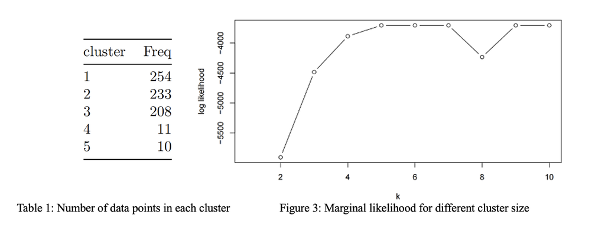

Using the cluster size 5, which data point belongs to each of the 5 clusters could be determined (Table 1).

## Gene-expression signatures

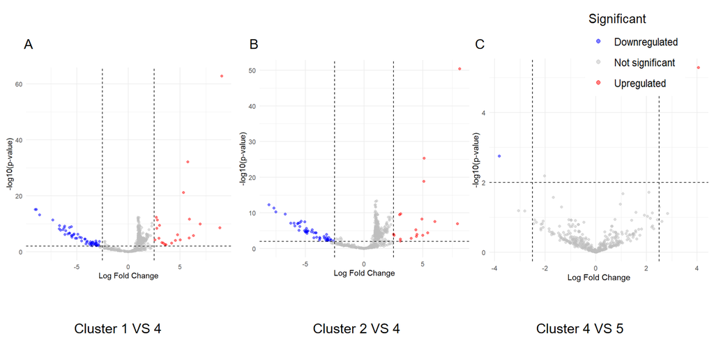

The Volcano plot for unique cluster comparisons. (A) Cluster 1 VS 4, (B) Cluster 2 VS 4, (C) Cluster 4 VS 5

Top 1 DEGs with largest log FC (absolute value) in clusters

| cluster1 up | cluster4 up | cluster5 up | cluster1 down |
| --- | --- | --- | --- |
| Cyp4b1 | Reg1 | Aqp1 | Crabp1 |

# Conclusion

### Conclusion

This study utilizing single-cell gene expression analysis through Principal Component Analysis (PCA) and Gaussian Mixture Model (GMM) clustering methods has significantly advanced our understanding of cellular complexity within breast cancer tumors. This approach has allowed for the intricate dissection of cellular heterogeneity, revealing how diverse cell populations contribute to the tumor environment.

The findings from this study are invaluable for the scientific community, offering a more nuanced view of tumor heterogeneity. By pinpointing specific cellular subtypes and their associated gene expressions, researchers can develop more targeted therapies that address the specific characteristics of different tumor cells. This tailored approach could lead to more effective treatments, improving patient outcomes in breast cancer therapy.

The use of advanced statistical techniques like PCA and GMM has proven to be essential in managing and interpreting complex datasets from high-throughput technologies like scRNA-seq. As we continue to refine these methodologies and enhance our computational tools, our capacity to decipher the complexities of cancer at the single-cell level will expand, paving the way for innovations in diagnostic and therapeutic strategies. This research not only represents a significant step forward in cancer research but also exemplifies the power of integrating advanced computational methods with biological research to solve some of the most challenging problems in medicine.

Although genes that are important for differentiating the clusters were identified, as the `limma` package prefers raw count data, the accuracy of the differential expression analysis might be affected due to the original expression data not being raw counts from single-cell sequencing and the normalization process not being explicitly defined. Additionally, while the analysis still relies on linear models to estimate the fold changes of each gene across different clusters, to enhance the accuracy of the results, some nonlinear methods could be applied in the future.

# Reference

[1]Levsky, Jeffrey M., et al. “Single-cell gene expression profiling.” Science 297.5582 (2002): 836-840.

[2]Abdi, H., & Williams, L. J. (2010). Principal component analysis. Wiley interdisciplinary reviews: computational statistics, 2(4), 433-459.

[3]Reynolds, D. A. (2009). Gaussian mixture models. Encyclopedia of biometrics, 741(659-663).

[4]McLachlan, G. J., & Krishnan, T. (2007). The EM algorithm and extensions. John Wiley & Sons.

[5]Smyth, G. K. (2005). Limma: linear models for microarray data. In Bioinformatics and computational biology solutions using R and Bioconductor (pp. 397-420). New York, NY: Springer New York.

# Supplementary

| up1 |
| --- |
| Cyp4b1 |
| Fabp4 |
| Rgs4 |
| Rgs5 |
| Higd1b |
| Myl9 |
| Kcnj8 |
| Tinagl1 |
| Sncg |
| Acta2 |
| Tmem37 |
| Ephx3 |
| Rgs16 |
| Errfi1 |
| X1810011H11Rik |
| Ifitm1 |
| Ankrd37 |
| Actg2 |
| Arhgdib |
| Dmp1 |
| H2.M9 |
| Emcn |

| down1 |
| --- |
| Lum |
| Mfap5 |
| Fbln2 |
| Crabp1 |
| Dcn |
| Smoc2 |
| Lrrc15 |
| Cpxm2 |
| Itm2a |
| Fbln1 |
| Rbp1 |
| Rnase4 |
| Gja1 |
| Serpinf1 |
| Cilp |
| Serpina3n |
| Ly6a |
| Olfml3 |
| Cpxm1 |
| Tnfaip6 |
| Hsd11b1 |
| Il33 |
| Pdgfrl |
| Ndufa4 |
| Ly6e |
| Igfbp6 |
| Apod |
| Fndc1 |
| Col1a1 |
| Mfap4 |
| Col3a1 |
| Cxcl14 |
| Lox |
| Itgbl1 |
| Pi16 |
| Eln |
| Cpz |
| Mmp2 |
| Col1a2 |
| Sfrp2 |
| Ly6c1 |
| Gas6 |
| Ctla2a |
| Mgst1 |
| Omd |
| Cd34 |
| Htra3 |
| Ccl8 |
| Cthrc1 |
| Fxyd6 |
| Ccl11 |
| Dpt |

| up2 |
| --- |
| Fabp4 |
| Rgs4 |
| Rgs5 |
| Higd1b |
| Myl9 |
| Kcnj8 |
| Tinagl1 |
| Sncg |
| Acta2 |
| Tmem37 |
| Ephx3 |
| Rgs16 |
| Errfi1 |
| X1810011H11Rik |
| Ifitm1 |
| Ankrd37 |
| Actg2 |
| Arhgdib |
| Dmp1 |
| H2.M9 |
| Emcn |
| Tspan7 |
| Ly6k |

| down2 |
| --- |
| Lum |
| Mfap5 |
| Fbln2 |
| Dcn |
| Smoc2 |
| Lrrc15 |
| Itm2a |
| Fbln1 |
| Rbp1 |
| Rnase4 |
| Gja1 |
| Serpinf1 |
| Cilp |
| Serpina3n |
| Ly6a |
| Olfml3 |
| Cpxm1 |
| Tnfaip6 |
| Hsd11b1 |
| Il33 |
| Ndufa4 |
| Ly6e |
| Igfbp6 |
| Apod |
| Fndc1 |
| Col1a1 |
| Mfap4 |
| Cxcl14 |
| Lox |
| Itgbl1 |
| Pi16 |
| Eln |
| Cpz |
| Mmp2 |
| Sfrp2 |
| Ly6c1 |
| Gas6 |
| Ctla2a |
| Mgst1 |
| Cd34 |
| Htra3 |
| Ccl8 |
| Cthrc1 |
| Fxyd6 |
| Ccl11 |
| Dpt |

| up3 |
| --- |
| Fabp4 |
| Rgs4 |
| Rgs5 |
| Higd1b |
| Myl9 |
| Kcnj8 |
| Tinagl1 |
| Sncg |
| Acta2 |
| Tmem37 |
| Ephx3 |
| Rgs16 |
| Errfi1 |
| X1810011H11Rik |
| Ifitm1 |
| Ankrd37 |
| Actg2 |
| Arhgdib |
| Dmp1 |
| Cd36 |
| Ccrl2 |
| H2.M9 |
| Cpa1 |
| Emcn |

| up4 |
| --- |
| Dpt |
| Ccl11 |
| Fxyd6 |
| Reg1 |
| Cthrc1 |
| Ccl8 |
| Sfrp1 |
| Reg3g |
| Htra3 |
| Efemp1 |
| Cd34 |
| Cxcl12 |
| Omd |
| Mgst1 |
| Ctla2a |
| Gas6 |
| Ly6c1 |
| Sfrp2 |
| Col1a2 |
| Mmp2 |
| Lrrn4cl |
| Cd55 |
| Cpz |
| Eln |
| Pi16 |
| Itgbl1 |
| Lox |
| Cxcl14 |
| Mfap4 |
| Col1a1 |
| Fndc1 |
| Apod |
| Igfbp6 |
| Ly6e |
| Ndufa4 |
| Pdgfrl |
| Il33 |
| Hsd11b1 |
| Tnfaip6 |
| Cpxm1 |
| Olfml3 |
| Ly6a |
| Serpina3n |
| Cilp |
| Serpinf1 |
| Gja1 |
| Rnase4 |
| Rbp1 |
| Fbln1 |
| Itm2a |
| Lrrc15 |
| Smoc2 |
| Dcn |
| Fbln2 |
| Mfap5 |
| Lum |

| up5 |
| --- |
| Dpt |
| Ccl11 |
| Fxyd6 |
| Cthrc1 |
| Ccl8 |
| Aqp1 |
| Ptgis |
| Lbp |
| Htra3 |
| Cd34 |
| Ogn |
| Omd |
| Mgst1 |
| S100a10 |
| Ctla2a |
| Gas6 |
| Ly6c1 |
| Sfrp2 |
| Col1a2 |
| Mmp2 |
| Igfbp2 |
| Cpz |
| Ackr3 |
| Eln |
| Pi16 |
| Itgbl1 |
| Lox |
| Cxcl14 |
| Hist1h2bc |
| Mfap4 |
| Col1a1 |
| Fndc1 |
| Apod |
| Igfbp6 |
| Ly6e |
| Ndufa4 |
| Pdgfrl |
| Col12a1 |
| Il33 |
| Hsd11b1 |
| Tnfaip6 |
| Cpxm1 |
| Olfml3 |
| Ly6a |
| Serpina3n |
| Cilp |
| Serpinf1 |
| Gja1 |
| Rnase4 |
| Rbp1 |
| Fbln1 |
| Itm2a |
| Cpxm2 |
| Lrrc15 |
| Smoc2 |
| Dcn |
| Crabp1 |
| Fbln2 |
| Mfap5 |
| Lum |

| down5 |
| --- |
| Tspan7 |
| Emcn |
| Mad2l1 |
| H2.M9 |
| Dmp1 |
| Arhgdib |
| Actg2 |
| Ankrd37 |
| Ifitm1 |
| X1810011H11Rik |
| Errfi1 |
| Tpm1 |
| Rgs16 |
| Ephx3 |
| Cxcl1 |
| Tmem37 |
| Acta2 |
| Sncg |
| Tinagl1 |
| Kcnj8 |
| Myl9 |
| Higd1b |
| Rgs5 |
| Rgs4 |
| Fabp4 |